# Dangerous and Damaging Weather Events

Lisa Anderson

May 23, 2015

### Summary

A review of the NOAA Storm Database, which contains data concerning weather events between 1950 and 2011, reveals the following relevant points concerning dangerous and damaging weather events:

- The most fatalities and injuries are caused by tornados
- The most expensive property damage is caused by floods
- The most expensive crop damage is caused by drought

### Data Processing

The data is read in from a local directory.

```r
setwd("~/Documents/Lisa Documents/Coursera_Data_Science/Rep_Research/assignment2")
data <- read.csv("repdata-data-StormData.csv.bz2")
head(data)
```

```
##   STATE__           BGN_DATE BGN_TIME TIME_ZONE COUNTY COUNTYNAME STATE
## 1       1  4/18/1950 0:00:00     0130       CST     97     MOBILE    AL
## 2       1  4/18/1950 0:00:00     0145       CST      3    BALDWIN    AL
## 3       1  2/20/1951 0:00:00     1600       CST     57    FAYETTE    AL
## 4       1   6/8/1951 0:00:00     0900       CST     89    MADISON    AL
## 5       1 11/15/1951 0:00:00     1500       CST     43    CULLMAN    AL
## 6       1 11/15/1951 0:00:00     2000       CST     77 LAUDERDALE    AL
##    EVTYPE BGN_RANGE BGN_AZI BGN_LOCATI END_DATE END_TIME COUNTY_END
## 1 TORNADO         0                                               0
## 2 TORNADO         0                                               0
## 3 TORNADO         0                                               0
## 4 TORNADO         0                                               0
## 5 TORNADO         0                                               0
## 6 TORNADO         0                                               0
##   COUNTYENDN END_RANGE END_AZI END_LOCATI LENGTH WIDTH F MAG FATALITIES
```

[output cut: 20 more lines]

The database contains a number of fields which are not necessary to this analysis and are removed. Additionally,the values in PROPDMG and CROPDMG must be transformed by the multiplier contained in PROPDMGEXP and CROPDMGEXP to obtain the full value of the damage, as follows:

- H or h = hundred
- K or k = thousand
- M or m = million
- B or b = billion

```r
Sdata <- data[,c(2,8,23:28)]
Sdata$tempPropDmg <- Sdata$PROPDMG
Sdata$PROPDMG <-1*Sdata$tempPropDmg
Sdata$PROPDMG[grepl("[Hh]",Sdata$PROPDMGEXP)] <- 100*Sdata$tempPropDmg[grepl("[Hh]",Sdata$PROPDMGEXP)]
Sdata$PROPDMG[grepl("[Kk]",Sdata$PROPDMGEXP)] <- 1000*Sdata$tempPropDmg[grepl("[Kk]",Sdata$PROPDMGEXP)]
Sdata$PROPDMG[grepl("[Mm]",Sdata$PROPDMGEXP)] <- 1000000*Sdata$tempPropDmg[grepl("[Mm]",Sdata$PROPDMGEXP)]
Sdata$PROPDMG[grepl("[Bb]",Sdata$PROPDMGEXP)] <- 1000000000*Sdata$tempPropDmg[grepl("[Bb]",Sdata$PROPDMGEXP)]

Sdata$tempCropDmg <- Sdata$CROPDMG
Sdata$CROPDMG <-1*Sdata$tempCropDmg
Sdata$CROPDMG[grepl("[Hh]",Sdata$CROPDMGEXP)] <- 100*Sdata$tempCropDmg[grepl("[Hh]",Sdata$CROPDMGEXP)]
Sdata$CROPDMG[grepl("[Kk]",Sdata$CROPDMGEXP)] <- 1000*Sdata$tempCropDmg[grepl("[Kk]",Sdata$CROPDMGEXP)]
Sdata$CROPDMG[grepl("[Mm]",Sdata$CROPDMGEXP)] <- 1000000*Sdata$tempCropDmg[grepl("[Mm]",Sdata$CROPDMGEXP)]
Sdata$CROPDMG[grepl("[Bb]",Sdata$CROPDMGEXP)] <- 1000000000*Sdata$tempCropDmg[grepl("[Bb]",Sdata$CROPDMGEXP)]
Sdata <- Sdata[,c(1:5,7)]
str(Sdata)
```

```
## 'data.frame':    902297 obs. of  6 variables:
##  $ BGN_DATE  : Factor w/ 16335 levels "1/1/1966 0:00:00",..: 6523 6523 4242 11116 2224 2224 2260 383 3980 3980 ...
##  $ EVTYPE    : Factor w/ 985 levels "   HIGH SURF ADVISORY",..: 834 834 834 834 834 834 834 834 834 834 ...
##  $ FATALITIES: num  0 0 0 0 0 0 0 0 1 0 ...
##  $ INJURIES  : num  15 0 2 2 2 6 1 0 14 0 ...
##  $ PROPDMG   : num  25000 2500 25000 2500 2500 2500 2500 2500 25000 25000 ...
##  $ CROPDMG   : num  0 0 0 0 0 0 0 0 0 0 ...
```

### Results

#### Most Dangerous Weather Events

```r
byfatalities <- aggregate(FATALITIES ~ EVTYPE, Sdata, sum)
head(byfatalities,n=15)
```

```
##                   EVTYPE FATALITIES
## 1     HIGH SURF ADVISORY          0
## 2          COASTAL FLOOD          0
## 3            FLASH FLOOD          0
## 4              LIGHTNING          0
## 5              TSTM WIND          0
## 6        TSTM WIND (G45)          0
## 7             WATERSPOUT          0
## 8                   WIND          0
## 9                      ?          0
## 10       ABNORMAL WARMTH          0
## 11        ABNORMALLY DRY          0
## 12        ABNORMALLY WET          0
## 13  ACCUMULATED SNOWFALL          0
## 14   AGRICULTURAL FREEZE          0
## 15         APACHE COUNTY          0
```

```r
tail(byfatalities,n=15)
```

```
##                      EVTYPE FATALITIES
## 971              WINTER MIX          0
## 972            WINTER STORM        206
## 973 WINTER STORM HIGH WINDS          1
## 974  WINTER STORM/HIGH WIND          0
## 975 WINTER STORM/HIGH WINDS          0
## 976           WINTER STORMS         10
## 977          Winter Weather          0
## 978          WINTER WEATHER         33
## 979      WINTER WEATHER MIX          0
## 980      WINTER WEATHER/MIX         28
## 981             WINTERY MIX          0
## 982              Wintry mix          0
## 983              Wintry Mix          0
## 984              WINTRY MIX          1
## 985                     WND          0
```

```r
byfatalities <- byfatalities[byfatalities$FATALITIES > 100,]
byinjuries <- aggregate(INJURIES ~ EVTYPE, Sdata, sum)
```

The following plot illustrates fatalities and injuries by type of weather event.

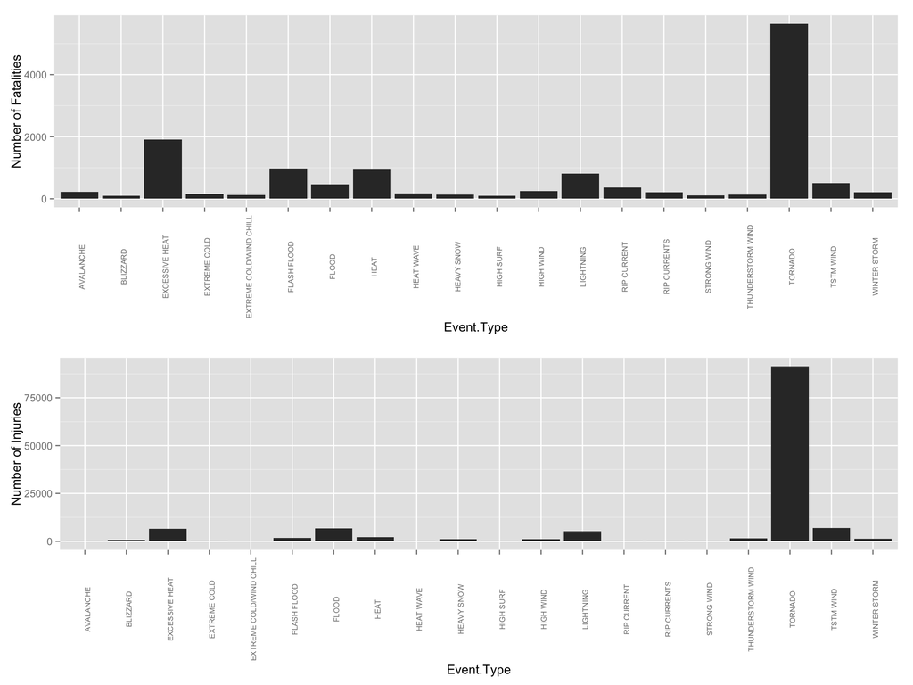

```r
harmData <- merge(x=byfatalities, y=byinjuries, all.x=TRUE)
hd1 <- harmData[,c(1,2)]
hd1$Harm <- "Fatality"
names(hd1) <- c("Event.Type", "Number", "Type.of.Harm")
hd2 <- harmData[,c(1,3)]
hd2$Harm <- "Injury"
names(hd2) <- c("Event.Type", "Number", "Type.of.Harm")

library(ggplot2)
p1 <- ggplot(hd1, aes(x=Event.Type, y=Number)) +
  geom_bar(stat="identity") + theme(axis.text.x = element_text(angle = 90, size = 7)) +
  ylab("Number of Fatalities")
p2 <- ggplot(hd2, aes(x=Event.Type, y=Number)) +
  geom_bar(stat="identity") + theme(axis.text.x = element_text(angle = 90, size = 7)) +
  ylab("Number of Injuries")

library(grid)
library(gridExtra)
grid.arrange(p1, p2, ncol=1,nrow=2)
```

The plot above shows that tornados caused the vast majority of fatalities and injuries in the United States between 1950 and 2011.

```r
library(lubridate)
Tdata <- Sdata[grepl("[Tt][Oo][Rr][Nn][Aa][Dd][Oo]",Sdata$EVTYPE),]
Tdata$date <- mdy(gsub("0:00:00.*$","",as.character(Tdata$BGN_DATE)))
Tdata$Year <- year(Tdata$date)
tornados <- aggregate(FATALITIES ~ Year,Tdata,sum)
yearsWithTornados <- nrow(tornados)
yearsWithTornados
```

```
## [1] 62
```

#### Most Damaging Weather Events

The columns PROPDMG and CROPDMG contain the observations we require to determine the most damaging weather events. Due to the number of unique weather event factors mentioned above, we choose to restrict our observations to weather events which caused at least $100 Million worth of property damage in the history of the database.

```r
bypropdmg <- aggregate(PROPDMG ~ EVTYPE, Sdata, sum)
bypropdmg <- bypropdmg[bypropdmg$PROPDMG > 100000000,]
bycropdmg <- aggregate(CROPDMG ~ EVTYPE, Sdata, sum)
```

The following plot illustrates property and crop damage by type of weather event.

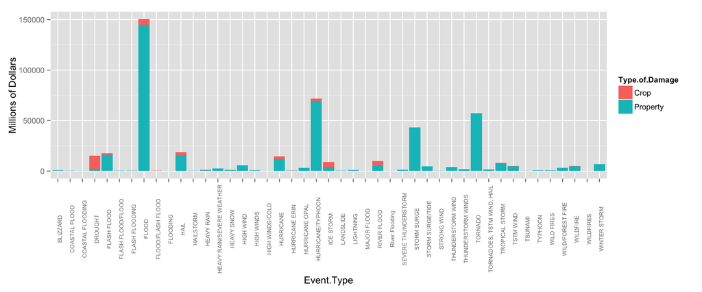

```r
costData <- merge(x=bypropdmg, y=bycropdmg, all.x=TRUE)
cd1 <- costData[,c(1,2)]
cd1$Damage <- "Property"
names(cd1) <- c("Event.Type", "Number", "Type.of.Damage")
cd2 <- costData[,c(1,3)]
cd2$Damage <- "Crop"
names(cd2) <- c("Event.Type", "Number", "Type.of.Damage")
costData <- rbind(cd1,cd2)

c1 <- ggplot(costData, aes(x=Event.Type, y=Number/1000000, fill=Type.of.Damage)) +
  geom_bar(stat="identity") + theme(axis.text.x = element_text(angle = 90, size = 7)) +
  ylab("Millions of Dollars")
c1
```

The plot above shows that floods cause the most property damage, while drought causes the most crop damage.